# Founders Cocaine vs Sham Expression Prep (RSEM)

Michael C. Saul (michael.saul [at] jax.org)

# 1 Background

## 1.1 Motivation

### 1.1.1 Purpose of analysis

This analysis is performed to preprocess straital expression data prior to expression linear modeling analysis.

# 2 Analysis

## 2.1 Setup

### 2.1.1 Working directory

All chunks will run in the working folder for this experiment.

```r
knitr::opts_knit$set(root.dir = "~/Box Sync/projects/founders_rnaseq/")
```

Getting current date

```r
current_date = format(Sys.time(),"%Y-%m-%d")
```

### 2.1.2 R libraries

Calling R libraries necessary for this analysis.

```r
library("limma")
library("GenomicRanges")
library("tibble")
library("tximport")
library("edgeR")
library("rhdf5")
```

```r
library("ggplot2")
library("gplots")
library("RColorBrewer")
library("GGally")
library("biomaRt")
library("ggbeeswarm")
```

# 3 Data Import

## 3.1 Pre-data import

### 3.1.1 Getting `norm_rank_transform` function

```r
norm_rank_transform = function(x, c = (0)) {
  stopifnot(is.numeric(x) & is.vector(x))
  x_noNA = which(!is.na(x))
  N = length(x_noNA)
  x[x_noNA] = qnorm((rank(x[x_noNA], ties.method = "random") - c) / (N - (2 * c) + 1))
  return(x)
}
```

## 3.2 Importing data

### 3.2.1 Importing phenotypic data

Importing phenotype data from the sample key.

```r
founders_pheno = read.table("sample_key_18-chesler-002.txt",
                            sep = "\t", header = TRUE, stringsAsFactors = FALSE)
row.names(founders_pheno) = founders_pheno$Name
```

### 3.2.2 Importing expression data

```r
# Preparing to read in aligned and summarized data
founders_RSEM_dir = "/Users/saulm/Documents/STAR_RSEM/transcript_RSEM_quant/"
founders_RSEM_files = list.files(path = founders_RSEM_dir, pattern = "isoforms.results$")
founders_RSEM_files = data.frame(base = founders_RSEM_files,
                                       stringsAsFactors = FALSE)
founders_RSEM_files$sample_id = gsub("^(GT18-\\d+)_.*-chesler-002.*$", "\\1", founders_RSEM_files$base)
row.names(founders_RSEM_files) = founders_RSEM_files$sample_id
founders_pheno$RSEM_path = paste(founders_RSEM_dir, founders_RSEM_files[founders_pheno$Name,"base"], sep = "")

# Getting founder strains for tximport
founder_strains = unique(founders_pheno$Strain)

file_i = read.table(founders_pheno[1,"RSEM_path"], header = TRUE, sep = "\t", stringsAsFactors = FALSE)
founders_tx2gene = data.frame(TXNAME = file_i$transcript_id,
                              GENEID = file_i$gene_id,
                              stringsAsFactors = FALSE)
founders_tx2gene = as_tibble(founders_tx2gene)

txi_i = tximport(files = founders_pheno[,"RSEM_path"],
                 type = "rsem",
                 tx2gene = founders_tx2gene,
                 countsFromAbundance = "lengthScaledTPM",
                 abundanceCol = "TPM",
                 ignoreTxVersion = TRUE)
```

```
## reading in files with read_tsv
```

```
## 1 2 3 4 5 6 7 8 9 10 11 12 13 14 15 16 17 18 19 20 21 22 23 24 25 26 27 28 29 30 31 32 33 34 35 36 37 38 39 40 41 42 43 44 45 46 47 48 49 50 51 52 53 54 55 56 57 58 59 60 61 62 63 64 65 66 67 68 69 70 71 72 73 74 75 76 77 78 79 80 81 82 83 84 85 86 87 88 89 90 91 92 93 94 95 96 97 98 99 100 101 1…
## transcripts missing from tx2gene: 1082
## summarizing abundance
## summarizing counts
## summarizing length
```

```r
gene_mat_i = txi_i$counts
colnames(gene_mat_i) = row.names(founders_RSEM_files)
founder_gene_counts = as.data.frame(gene_mat_i)
rm(list = c("txi_i", "file_i", "gene_mat_i"))

founder_gene_counts = as.matrix(founder_gene_counts[which(rowSums(is.na(founder_gene_counts)) == 0),founders_pheno$Name])
founder_ERCC_counts = founder_gene_counts[grep("ERCC", row.names(founder_gene_counts)),]
founder_gene_counts = founder_gene_counts[grep("^ENSMUSG", row.names(founder_gene_counts)),]
row.names(founder_gene_counts) = gsub("^(ENSMUSG\\d{11})_.*$", "\\1", row.names(founder_gene_counts))
```

Importing transcript data to transcript-level abundances.

```r
# Preparing to read in aligned and summarized data
txi_i = tximport(files = founders_pheno[,"RSEM_path"],
                 type = "rsem",
                 txOut = TRUE,
                 countsFromAbundance = "lengthScaledTPM",
                 abundanceCol = "TPM",
                 ignoreTxVersion = TRUE)
```

```
## reading in files with read_tsv
```

```
## 1 2 3 4 5 6 7 8 9 10 11 12 13 14 15 16 17 18 19 20 21 22 23 24 25 26 27 28 29 30 31 32 33 34 35 36 37 38 39 40 41 42 43 44 45 46 47 48 49 50 51 52 53 54 55 56 57 58 59 60 61 62 63 64 65 66 67 68 69 70 71 72 73 74 75 76 77 78 79 80 81 82 83 84 85 86 87 88 89 90 91 92 93 94 95 96 97 98 99 100 101 1…
```

```r
trans_mat_i = txi_i$counts
colnames(trans_mat_i) = row.names(founders_RSEM_files)
founder_trans_counts = as.data.frame(trans_mat_i)
rm(list = c("txi_i", "trans_mat_i"))

founder_trans_counts = as.matrix(founder_trans_counts[which(rowSums(is.na(founder_trans_counts)) == 0),founders_pheno$Name])
founder_ERCC_trans_counts = founder_trans_counts[grep("ERCC", row.names(founder_trans_counts)),]
founder_trans_counts = founder_trans_counts[grep("^ENSMUST", row.names(founder_trans_counts)),]
row.names(founder_trans_counts) = gsub("^(ENSMUST\\d{11})_.*$", "\\1", row.names(founder_trans_counts))
founders_trans_dge = DGEList(as.matrix(founder_trans_counts))
founders_dge_trans_filter = filterByExpr(founders_trans_dge)
founders_dge_trans_filter = founders_dge_trans_filter[row.names(founders_trans_dge)]

founders_dge_trans_notkept_rows = founders_trans_dge[which(!(founders_dge_trans_filter)),]
founders_trans_dge = founders_trans_dge[which(founders_dge_trans_filter),]
founders_trans_dge = calcNormFactors(founders_trans_dge, method = "TMM")
founders_trans_voom = voom(founders_trans_dge)
```

Preparing edgeR DGEList from the data at the gene level.

```r
founders_pheno_counts_agree = length(which(row.names(founders_pheno) == colnames(founder_gene_counts))) == ncol(founder_gene_counts)
founders_dge = DGEList(as.matrix(founder_gene_counts))
founders_dge$samples = cbind(founders_dge$samples, founders_pheno[,-1])
ifelse(founders_pheno_counts_agree,"Counts and pheno data have same IDs.", "Counts and pheno data have different IDs.")
```

```
## [1] "Counts and pheno data have same IDs."
```

Saving RSEM table.

```r
# Saving RSEM tables
saveRDS(founder_gene_counts, paste("founders_RSEM_table_", current_date,".RDS", sep = ""), compress = "xz")
saveRDS(founder_ERCC_counts, paste("founders_RSEM_ERCC_table_", current_date,".RDS", sep = ""), compress = "xz")
```

Getting CPM values for the data.

```r
founders_DGE_norm = calcNormFactors(founders_dge, method = "TMM")
founders_cpm = as.data.frame(cpm(founders_dge, normalized.lib.sizes = TRUE))
```

### 3.2.3 QC of expression data

Starting with the data from the `Strain` factor.

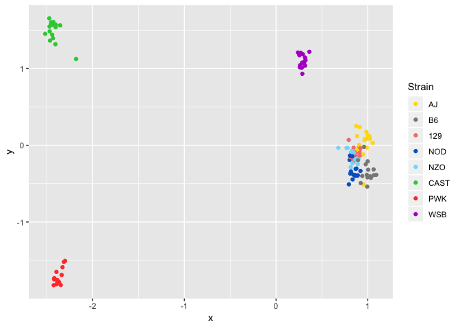

```r
founders_sex = founders_pheno$Sex
founders_sex_colors = ifelse(founders_sex == "F", "#3399CC","#FFCC33")
founders_strain = gsub("/","",founders_pheno$Strain)
strain_key = readRDS("~/Box Sync/CC_DO_founders/cc_do_founders_key.RDS")
row.names(strain_key) = strain_key$collaborative_cross_abbreviation
founders_straincolors = strain_key[gsub("/","",founders_pheno[,"Strain"]),"collaborative_cross_color_broman"]

founders_MDS = plotMDS(founders_dge, plot = FALSE)
founders_MDS_df = data.frame(row.names = names(founders_MDS$x),
                             Sample = names(founders_MDS$x),
                             Strain = factor(gsub("/","",founders_pheno[names(founders_MDS$x),"Strain"]),
                                             levels = strain_key$collaborative_cross_abbreviation,
                                             ordered = TRUE),
                             x = founders_MDS$x, y = founders_MDS$y)

saveRDS(founders_MDS_df,
        paste("~/Box Sync/projects/founders_rnaseq/founders_MDS_df_",current_date,".RDS",sep=""))

founders_MDS_plot = ggplot(data = founders_MDS_df, aes(x = x, y = y, color = Strain)) +
  geom_point() +
  scale_color_manual(values = strain_key$collaborative_cross_color_broman)

founders_MDS_plot
```

The MDS clearly reiterates the known relationships between the strains. The wild-derived strains cluster separate from the domesticated strains, but WSB clusters closest to the other *domesticus* subspecies strains.

```r
# Setting up biomaRt
chr_maRt = useMart(biomart = "ENSEMBL_MART_ENSEMBL",
                   host = "oct2018.archive.ensembl.org",
                   dataset = "mmusculus_gene_ensembl")
chr_maRt_filter = "chromosome_name"
chr_maRt_attributes = c("ensembl_gene_id")

# Setting heatmap colors
heatmapColors = colorRampPalette(c("#660066","#FFFFFF"))(n=299)

# Getting genes on various combinations of chromosome
chr1_genes = as.character(getBM(chr_maRt_attributes, chr_maRt_filter, c("1"), chr_maRt)$ensembl_gene_id)
chrX_genes = as.character(getBM(chr_maRt_attributes, chr_maRt_filter, c("X"), chr_maRt)$ensembl_gene_id)
chrY_genes = as.character(getBM(chr_maRt_attributes, chr_maRt_filter, c("Y"), chr_maRt)$ensembl_gene_id)
autosomal_genes = as.character(getBM(chr_maRt_attributes, chr_maRt_filter, as.character(1:19), chr_maRt)$ensembl_gene_id)
```

Now clustering samples together based upon their autosomal expression correlations.

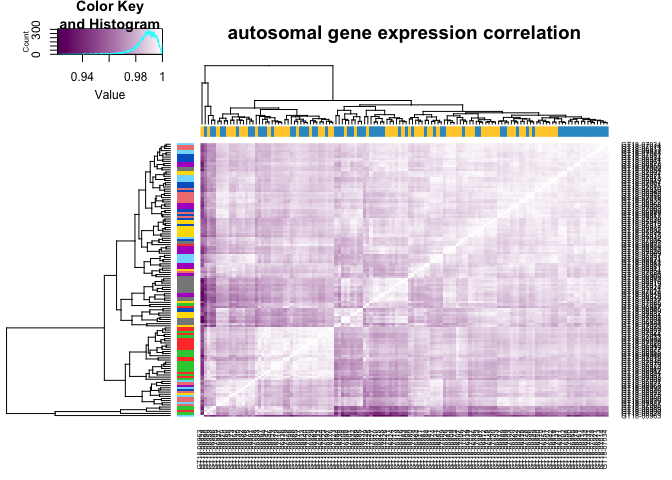

```r
# Filtering chr1 genes and looking at heatmap
autosomal_genes_dge = autosomal_genes[which(autosomal_genes %in% row.names(founders_dge))]
autosomal_genes_cpm = founders_cpm[autosomal_genes_dge,]
autosomal_genes_cpm = autosomal_genes_cpm[which(rowSums(autosomal_genes_cpm >= 1) >= 16),]
heatmap.2(cor(autosomal_genes_cpm),
          trace = "none",
          col = heatmapColors,
          dendrogram = "both",
          ColSideColors = founders_sex_colors,
          RowSideColors = founders_straincolors,
          main = "autosomal gene expression correlation")
```

The samples hold together fairly well based upon strain. Intercorrelations appear moderately strain-dependent. A/J appears to cluster separate to the other strains, and for some reason, A/J has relatively low correlation with other domesticated *domesticus* lines such as 129 and NZO. Still, this is a satisfactory result.

Earlier work with DO animals has demonstrated differential alignment due to *Rn7s1* (ENSMUSG00000099021) and *Rn7s2* (ENSMUSG00000099250). Trying the same correlation without these genes.

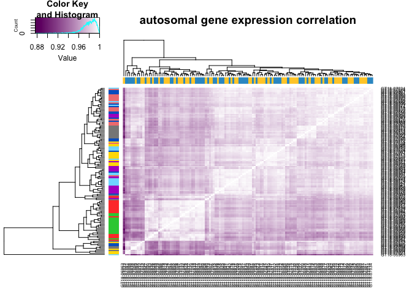

```r
heatmap.2(cor(autosomal_genes_cpm[-1 * which(row.names(autosomal_genes_cpm) %in% c("ENSMUSG00000099021","ENSMUSG00000099250")),]),
          trace = "none",
          col = heatmapColors,
          dendrogram = "both",
          ColSideColors = founders_sex_colors,
          RowSideColors = founders_straincolors,
          main = "autosomal gene expression correlation")
```

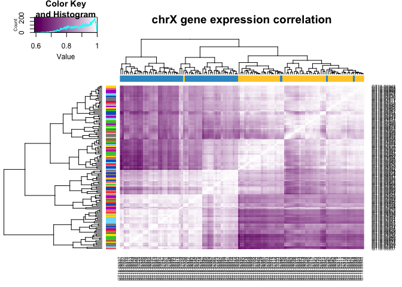

```r
# Filtering chrX genes and looking at heatmap
chrX_genes_dge = chrX_genes[which(chrX_genes %in% row.names(founders_dge))]
chrX_genes_cpm = founders_cpm[chrX_genes_dge,]
chrX_genes_cpm = chrX_genes_cpm[which(rowSums(chrX_genes_cpm >= 1) >= 16),]
heatmap.2(cor(chrX_genes_cpm),
          trace = "none",
          col = heatmapColors,
          dendrogram = "both",
          ColSideColors = founders_sex_colors,
          RowSideColors = founders_straincolors,
          main = "chrX gene expression correlation")
```

With only a couple of exceptions, the chromosome X data do stratify between the sexes. It’s possible there’s X aneuploidy here, so the same attempt should be done on the Y chromosome.

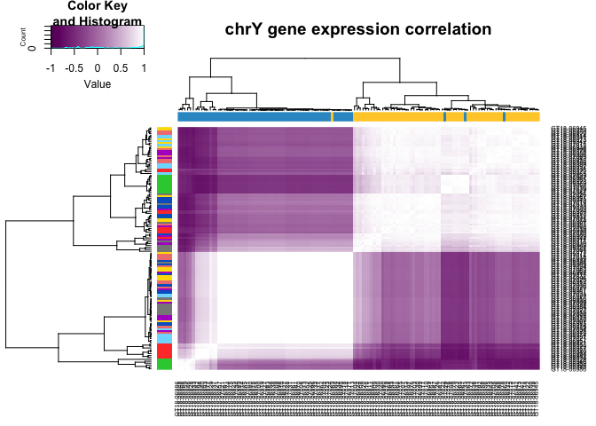

```r
# Filtering chrX genes and looking at heatmap
chrY_genes_dge = chrY_genes[which(chrY_genes %in% row.names(founders_dge))]
chrY_genes_cpm = founders_cpm[chrY_genes_dge,]
chrY_genes_cpm = chrY_genes_cpm[which(rowSums(chrY_genes_cpm >= 1) >= 16),]
heatmap.2(cor(chrY_genes_cpm),
          trace = "none",
          col = heatmapColors,
          dendrogram = "both",
          RowSideColors = founders_straincolors,
          ColSideColors = founders_sex_colors,
          main = "chrY gene expression correlation")
```

These seem consistent, indicating that missexing is more likely. Going with the chromosome Y sex.

```r
founders_chrY_dist = dist(cor(chrY_genes_cpm))
founders_chrY_hclust = hclust(founders_chrY_dist)
founders_chrY_treecut = cutree(founders_chrY_hclust, k = 2)
founders_chrY_table = table(paste(founders_sex, founders_chrY_treecut))
```

2 is female, 1 is male.

```r
founders_chrY_sex = ifelse(founders_chrY_treecut == 1, "M", "F")
names(founders_chrY_sex) = names(founders_chrY_treecut)
founders_pheno$chrY_sex = founders_chrY_sex[row.names(founders_pheno)]
```

There appears to be a problem with choroid plexus contamination. Building a nuissance covariate using the geometric mean of an unambiguous set of markers for the choroid plexus contamination. Using the Sathyanesan et al., 2012 paper from *Translational Psychiatry*, which reports that *Kl* and *Ttr* are good and unambiguous markers. Their Ensembl gene IDs are ENSMUSG00000058488 and ENSMUSG00000061808 respectively.

Calculating log-mean of these values.

```r
choroid_plexus_genes = c("ENSMUSG00000058488","ENSMUSG00000061808")
logmean = function(x) {
  return(exp(mean(log(x))))
}
choroid_plexus_covariate = apply(cpm(founders_dge[choroid_plexus_genes,]), MARGIN = 2, FUN = logmean)
founders_pheno$choroid_plexus_covariate = choroid_plexus_covariate[row.names(founders_pheno)]
```

Filtering expression data and phenotype data in preparation for expression modeling work, then calculating TMM normalization values.

```r
founders_dge_filter = filterByExpr(founders_dge)
founders_dge_filter = founders_dge_filter[row.names(founders_dge)]
# Filtering out rRNA data
founders_dge_filter[c("ENSMUSG00000099021","ENSMUSG00000099250")] = FALSE
DO_dge_notkept_rows = founders_dge[which(!(founders_dge_filter)),]
founders_dge = founders_dge[which(founders_dge_filter),]
founders_dge = calcNormFactors(founders_dge, method = "TMM")
```

Doing a log-2 transform and a normal rank-transform of the data.

```r
founders_voom = voom(founders_dge)
```

```r
founders_normrt = matrix(nrow = nrow(founders_voom), ncol = ncol(founders_voom))
rownames(founders_normrt) = rownames(founders_voom)
colnames(founders_normrt) = colnames(founders_voom)
for (i in 1:nrow(founders_normrt)) {
  gene_i = rownames(founders_normrt)[i]
  founders_normrt[i,] = norm_rank_transform(founders_voom$E[gene_i,colnames(founders_normrt)])
}
founders_normrt = founders_normrt[,colnames(founders_voom)]
```

Collapsing and reordering the phenotype data to the same size as the `voom` object

```r
founders_pheno = founders_pheno[colnames(founders_voom),]
```

### 3.2.4 Saving data for downstream analysis.

Saving `voom` and `DGEList` objects as well as the phenotype data frame.

```r
saveRDS(founders_dge,paste("./expression_study/founders_",ncol(founders_dge),"_RSEM_DGEList_",current_date,".RDS",sep=""),compress="xz")
saveRDS(founders_voom,paste("./expression_study/founders_",ncol(founders_voom),"_RSEM_voom_",current_date,".RDS",sep=""),compress="xz")
saveRDS(founders_normrt,paste("./expression_study/founders_",ncol(founders_normrt),"_RSEM_normrt_",current_date,".RDS",sep=""),compress="xz")
saveRDS(founders_pheno,paste("./expression_study/founders_",nrow(founders_pheno),"_RSEM_pheno_",current_date,".RDS",sep=""),compress="xz")
saveRDS(founders_trans_dge,paste("./expression_study/founders_trans_",ncol(founders_trans_dge),"_RSEM_DGEList_",current_date,".RDS",sep=""),compress="xz")
saveRDS(founders_trans_voom,paste("./expression_study/founders_trans_",ncol(founders_trans_voom),"_RSEM_trans_voom_",current_date,".RDS",sep=""),compress="xz")
```

## 3.3 Reproducibility Information

### 3.3.1 R session and OS information

```r
founders_expression_prep_sessionInfo
```

[output not shown]

### 3.3.2 Document Control

This document was prepared using RMarkdown in RStudio.